# Los Angeles airport passenger prediction with Box Jenkins

03/11/2020

## Overview

1. Presentation of the project
2. Description of the time series and data preparation
3. Stationarity analysis
4. Box-Jenkins methodology to build a SARIMA process
5. Prediction
6. Conclusion

## Presentation of the project

- **Data** : For this project, we used a dataset hosted by the city of Los Angeles.
- The organization has an open data platform and they update their information according the amount of data that is brought in. We found the dataset trough an open dataset in [Kaggle website](https://www.kaggle.com/cityofLA/los-angeles-international-airport-data). We download the data and upload it in our working github repository. The dataset has only 3 notebooks written in Python and only one notebook has implemented a prediction using SARIMA model.
- Thus, it seemed relevant to us to write this script in R by applying the Box Jenkins method in order to make predictions on this dataset using the methods seen during the Time Series and Business Data course by Anne VANHEMS. If this script doesn’t contain a lot of errors, we hope to be able to publish it on the platform.

## Lax Airport

[figure not shown]

Lax Airport

## Outline :

- After loading the data, we are going to analyze the data, visualize our data to understand it better. (Chapter 1) > - Then, we will focus on the stationary analysis by including graphs and tables to justify our analysis. We will transform the data in order to reach stationary.(Chapter 2)
- The stationary reached, we will then apply Box-Jenkins methodology to build an ARMA process on the modified data and select the best model (Chapter 3). -After that, we will focus validate the model with an in-sample and out of sample analysis and do prediction to predict the number of passengers for future dates (Chapter 4)

## 1. Description of the time series and data preparation

### 1.1 Load the data

- As mentioned below, we load the data from our github repository …

```r
Lax_init <- read.csv("data/los-angeles-international-airport-passenger-traffic-by-terminal.csv")
Lax_init %>% head(n=3)
```

```
##           DataExtractDate            ReportPeriod          Terminal
## 1 2014-05-01T00:00:00.000 2006-01-01T00:00:00.000 Imperial Terminal
## 2 2014-05-01T00:00:00.000 2006-01-01T00:00:00.000 Imperial Terminal
## 3 2014-05-01T00:00:00.000 2006-01-01T00:00:00.000    Misc. Terminal
##   Arrival_Departure Domestic_International Passenger_Count
## 1           Arrival               Domestic             490
## 2         Departure               Domestic             498
## 3           Arrival               Domestic             753
```

```r
Lax_init %>% str
```

```
## 'data.frame':    5870 obs. of  6 variables:
##  $ DataExtractDate       : Factor w/ 60 levels "2014-05-01T00:00:00.000",..: 1 1 1 1 1 1 1 1 1 1 ...
##  $ ReportPeriod          : Factor w/ 159 levels "2006-01-01T00:00:00.000",..: 1 1 1 1 1 1 1 1 1 1 ...
##  $ Terminal              : Factor w/ 11 levels "Imperial Terminal",..: 1 1 2 2 3 3 3 4 4 4 ...
##  $ Arrival_Departure     : Factor w/ 2 levels "Arrival","Departure": 1 2 1 2 1 2 2 1 1 2 ...
##  $ Domestic_International: Factor w/ 2 levels "Domestic","International": 1 1 1 1 1 1 2 1 2 1 ...
##  $ Passenger_Count       : int  490 498 753 688 401535 389745 561 98991 163067 93672 ...
```

The row data we have loaded contains 5870 observation for the 8 following features:  
- DataExtractDate  
- ReportPeriod  
- Terminal  
- Arrival_Departure - Domestic_International  
- Passenger_Count - year and month

- We check if there is null value

```r
Lax_init %>% anyNA
## [1] FALSE
```

We don’t have NA value.

## 1.2 Data preparation

- In order to use ts package in R, we have to do some Data preparation.
- Since we want to predict the **number of passenger** with our model, we will only keep the feature **Passenger Count** and **Report Period** associated to each observation.
- So first we convert the Report Perdiod feature into a Date type.

```r
Lax_init[,2]<-Lax_init[,2] %>% as.Date()
```

- Then we create 2 new column for the year and the month from this Report Period and convert the initial dataset into a Data table.

```r
Lax_init$year<-as.numeric(format(Lax_init[,2],'%Y'))
Lax_init$months<-months(Lax_init[,2])
Lax_init %>% setDT
```

-We create a new Lax dataset with only the data we are interested in for the prediction.

```r
Lax_data=Lax_init[, lapply(.SD, sum, na.rm=TRUE), by=list(year,months),.SDcols=c("Passenger_Count")]
```

- We verify that the data of our transformation fit well with the original data.

```r
sum(Lax_init[months=="janvier"&year==2006][,6])
```

```
## [1] 4756159
```

```r
Lax_data[1]
```

```
##    year  months Passenger_Count
## 1: 2006 janvier         4756159
```

It is the same ! We can pass to load our data our ts package and do our first plot.

## 1.3 Load into ts model

```r
traf <- ts(Lax_data[,3], start=c(2006,1), frequency=12)
str(traf)
```

```
##  Time-Series [1:159, 1] from 2006 to 2019: 4756159 4250155 5090294 5087874 5177408 5510023 5919723 5745243 4707983 4898421 ...
##  - attr(*, "dimnames")=List of 2
##   ..$ : NULL
##   ..$ : chr "Passenger_Count"
```

- Our time series data starts at date 2006 January and ends at date 2019 mars. It’s frequency is monthly.

## 1.4 First plot : Passenger traffic at LAX airport

From this first plot, we can first notice that this time series has for the most part of it a **positive linear trend**, a **multiplicative seasonal patterns**, and **some irregular patterns**. This plot suggests to use what we cal a SARIMA model to do our forecasting.

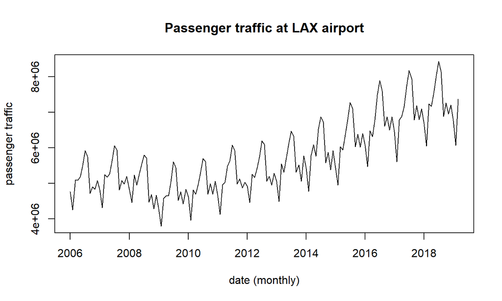

## 1. 5 Decomposition in trend, seasonality and random component

We find the same conclusion from visual observation of time series : i.e a mainly positive linar trend over time, a seasonal patterns with some irregular patterns in the random component.

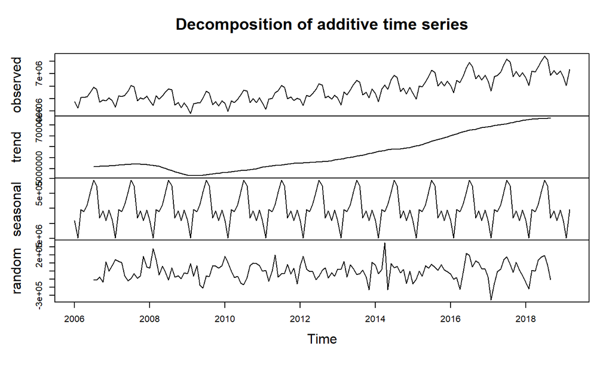

## 1.6 Visualization of the frequency

- Our final plot for this description part will be the visualization of the seasonality within our time series with month plot function. Monthplot function plots the average value obtain at each month (season).

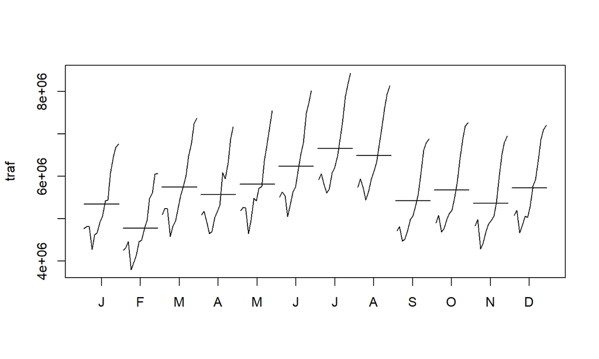

We can notice that in average, passenger traffic tends to decrease between January and February then increases between march and august to decrease in the month of September and then remain stable between October and December.

This concludes our description part. Let’s move to stationary analysis and transformation.

[figure not shown]

## 2. Stationary ?

- A **stationary** process have no trend **in mean**, and no **trend in variance** and so auto-covariances **do not depend on time**, but only on the **difference of time**.
- Let’s check the auto and partial auto-correlation function (ACF and PACF) of our raw data in order to confirm what we have observed from our first plot.

- Blue : confidence interval. If the values were inside the interval, it would mean that there enough close to zeros to be non significant.  
- From the ACF, we see that values are outside the confidence interval represented by the blue lines. It means that they are all different from zero and so significant, i.e they depend on time. We can have the same observation from pacf.

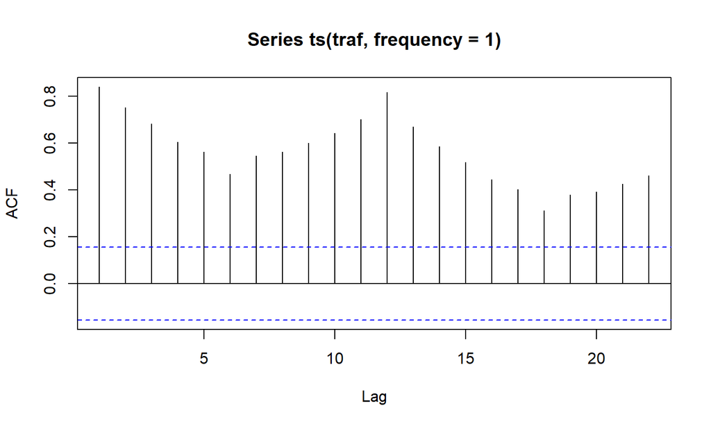

```r
acf(ts(traf, frequency=1))
```

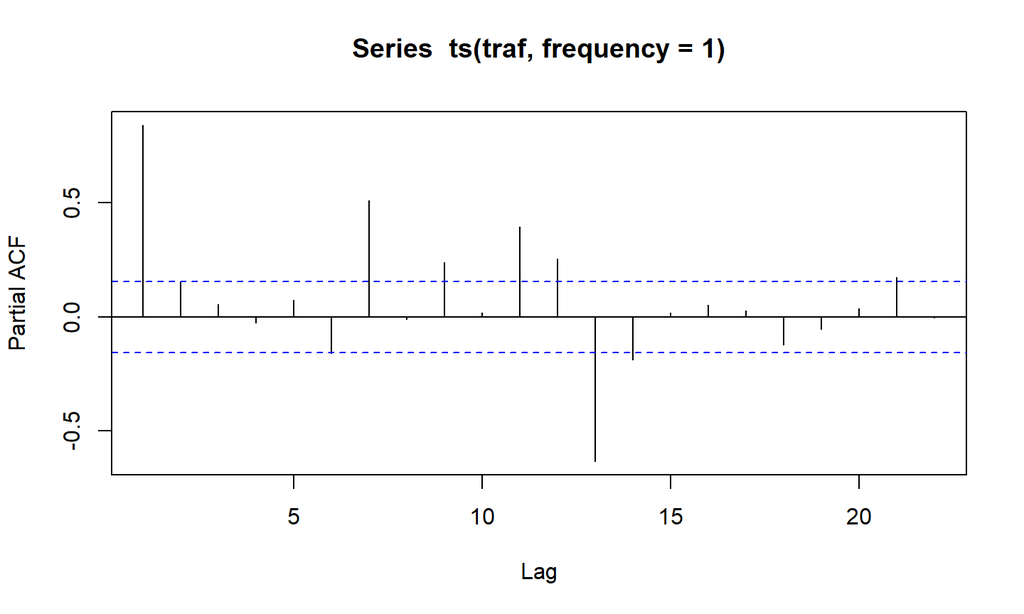

```r
pacf(ts(traf, frequency=1))
```

## 2.1 Logarithm transformation

We perform a logarithmic transformation to remove the cycle amplification. The range cycle has become stable

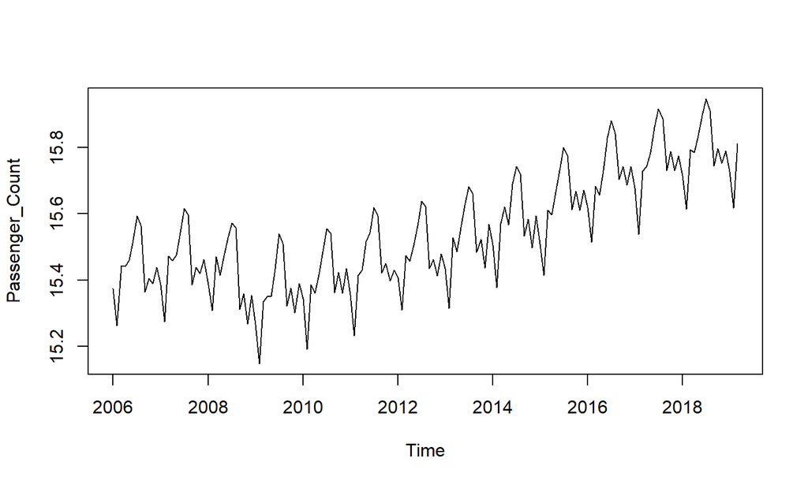

```r
ltraf <- log(traf)
plot.ts(ltraf)
```

There is still the presence of a trend and a seasonal component. This trend seems to be deterministic, linear and non-stochastic (but we will use a stochastic modelisation for the trend using integration within ARIMA)

The serie is always a non-stationary series. let’s confirm it with Autocorrelograms

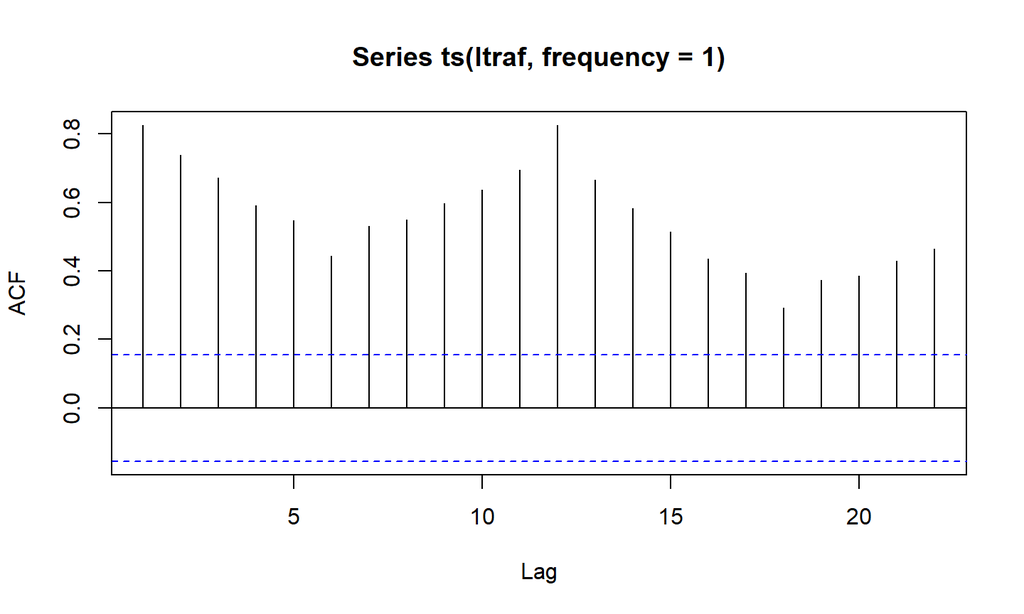

```r
acf(ts(ltraf, frequency=1))
```

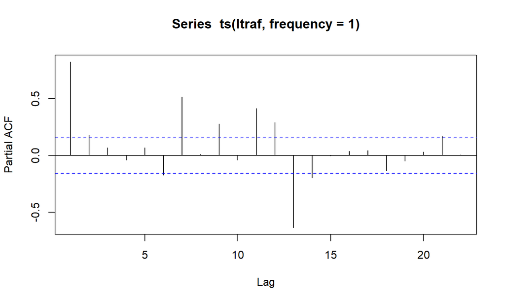

```r
pacf(ts(ltraf, frequency=1))
```

## 2.2 First order difference : remove the trend

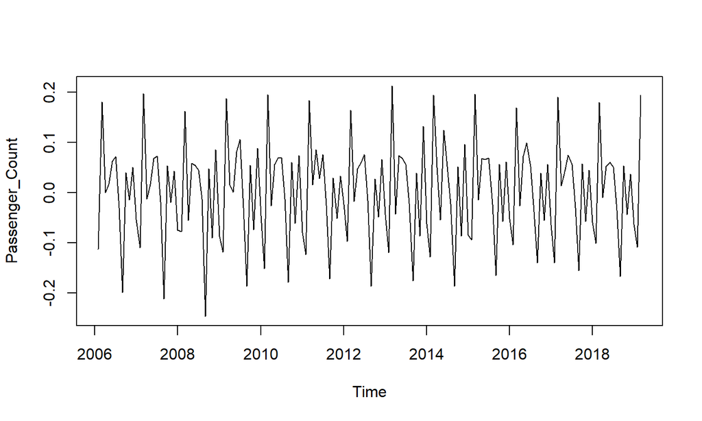

```r
dltraf_1 <- diff(ltraf, 1)
plot(dltraf_1)
```

The trend component seems to have disappeared, not the seasonality at t=12

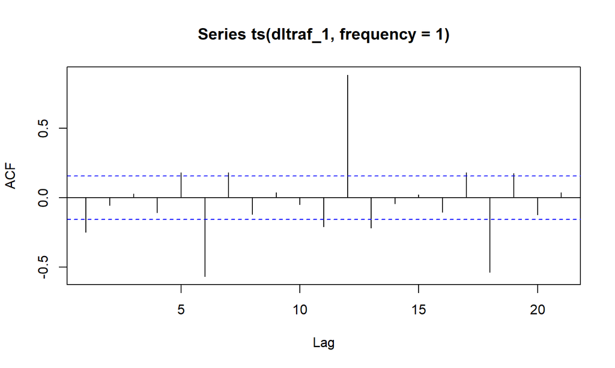

```r
acf(ts(dltraf_1, frequency=1))
```

We will use a stochastic modelisation for the trend using integration within **SARIMA**

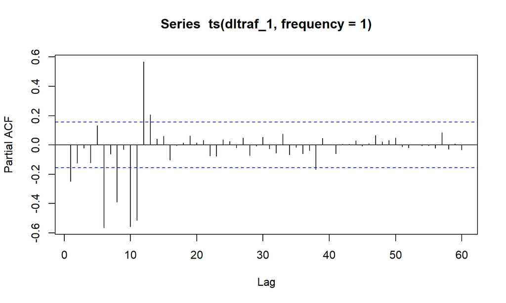

```r
pacf(ts(dltraf_1, frequency=1), lag.max = 60)
```

## 2.3 A look at the seasonal component

```r
dltraf_12 <- diff(dltraf_1, 12)
library(tseries)
kpss.test(dltraf_12)
```

```
##
##  KPSS Test for Level Stationarity
##
## data:  dltraf_12
## KPSS Level = 0.043809, Truncation lag parameter = 4, p-value = 0.1
```

stationnary, we accept H0 and we choose as seasonality s=12. Now we have found a series which is stationary. We can move the identification step

## 3. Box-Jenkins methodology to build a SARIMA process

### 3.1 SARIMA model selection from ACF/PACF plots

In this part, we will apply our first identification to build our SARIMA (p,d,q)(P,D,Q)[S] model

We will apply those rules :  
Identifying the order of difference:

- **d** is equal to order we have taken the difference in order to remove the trend Identifying the number of AR and MA terms :
- **p** is equal to the first lag where the PACF value is above the significance level.
- **q** is equal to the first lag where the ACF value is above the significance level.

Identifying the seasonal part of the model:

- **S** is equal to the ACF lag with the highest value (typicaly at a high lag).
- **D** is equal to the seasonality difference
- **P** is equal at the number of order where the PACF remain significant.
- **Q** is equal at the number of order where the ACF remain significant.

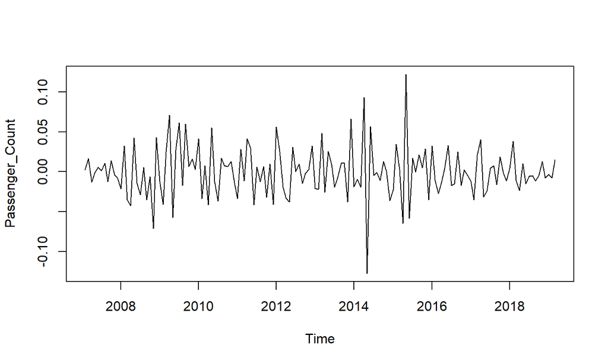

```r
plot(dltraf_12)
```

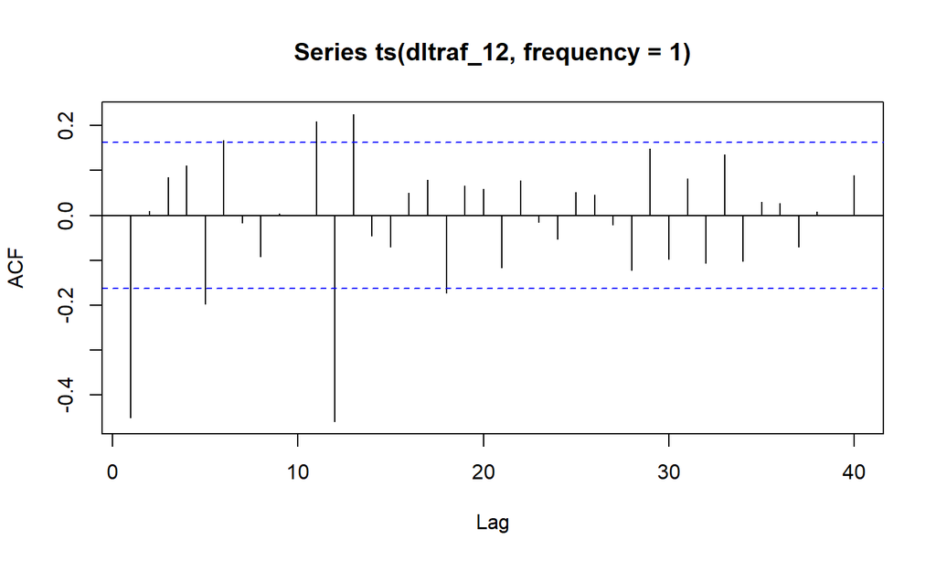

```r
acf(ts(dltraf_12, frequency=1), lag.max = 40)
```

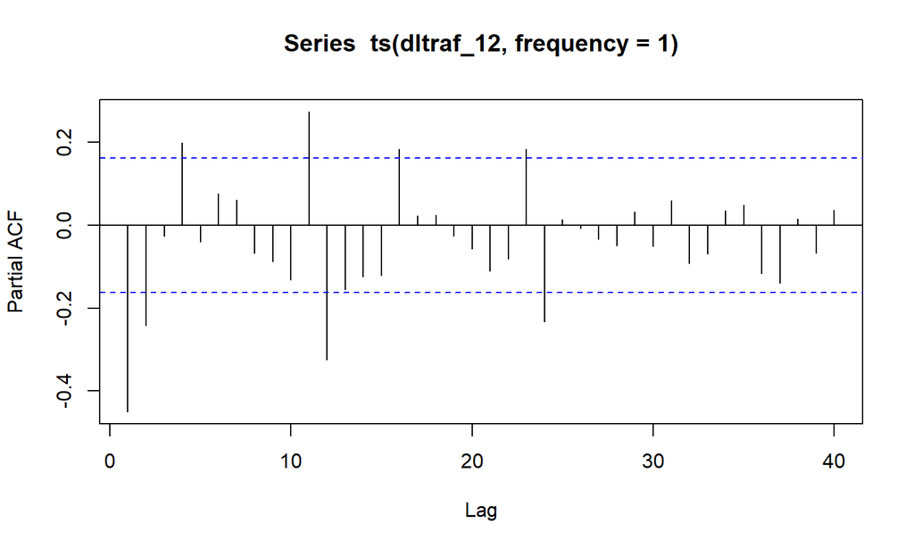

```r
pacf(ts(dltraf_12, frequency=1), lag.max = 40)
```

First estimation :

- **q=1** #MA because for k>(q=1), acf(ts) = 0 (taking ac count of the seasonality)
- **p=2** #AR because for k>(q=2), pacf(ts) = 0 (taking ac count of the seasonality)
- **d=1** #we removed trend by taking the diff of order 1
- **Q=1** #MA because some significant coefficients in the ACF remain at order 12 (but not at order 24)
- **P=2** #AR because some significant coefficients in the PACF remain at order 12 & at order 24
- **D=1** #(seasonality diff) we removed seasonality diff by taking the diff or order 1

## 3.2 Model building

Now that we have identified our parameters, we can build our arima model. We use P=1 as we got an error with P=2 using method = ‘ML’.

```r
mod1 <- arima(ltraf, c(2, 1, 1),seasonal = list(order = c(1, 1, 1), period = 12), method='ML')
mod1
```

```
##
## Call:
## arima(x = ltraf, order = c(2, 1, 1), seasonal = list(order = c(1, 1, 1), period = 12),
##     method = "ML")
##
## Coefficients:
##           ar1      ar2      ma1    sar1     sma1
##       -0.4109  -0.1961  -0.0842  0.0665  -0.8480
## s.e.   0.2256   0.1185   0.2195  0.1139   0.1182
##
## sigma^2 estimated as 0.0004553:  log likelihood = 347.52,  aic = -685.05
```

We have an Akaike Information Criteria (AIC) of -685. AIC is widely used measure of a statistical model. It basically quantifies 1) the goodness of fit, and 2) the simplicity/parsimony, of the model into a single statistic which will be compared with other AIC of different model (the lower the better).

Let’s fit our model with our data and plot it compared to real data (black line for real data and red line for model estimation)

This first plot is rather reassuring as for the good identification of our parameters. The model seems to follow our actual data well. However, we can observe that some parts of the model do not fit well data based on the real data for instance, at year 2009.

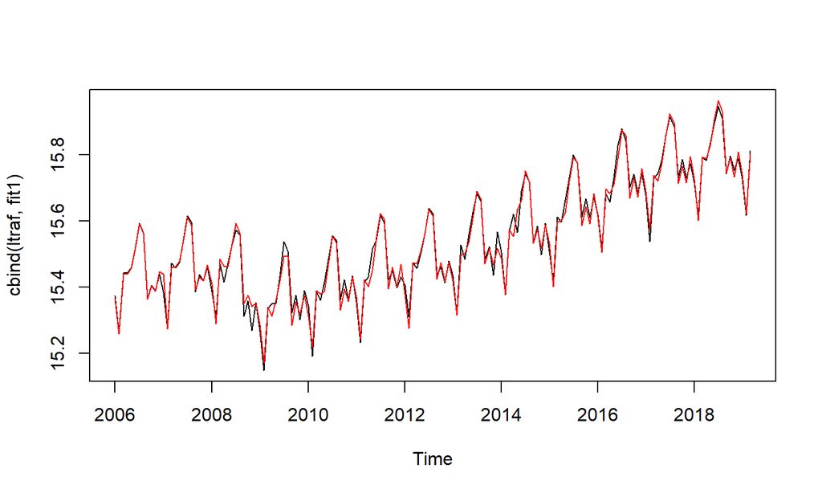

```r
fit1 <- fitted(mod1)
plot.ts(cbind(ltraf,fit1),plot.type='single',col=c('black','red'))
```

## 3.3 Validation of our model

We should now pass to test the significance of our coefficient. First call our coef from our model

```r
mod1$coef
```

```
##         ar1         ar2         ma1        sar1        sma1
## -0.41093841 -0.19609459 -0.08416079  0.06645508 -0.84798167
```

```r
mod1$var.coef
```

```
##                ar1           ar2           ma1          sar1          sma1
## ar1   0.0509079363  0.0204434779 -0.0461009866 -0.0006709274 -0.0015930694
## ar2   0.0204434779  0.0140409957 -0.0190395404 -0.0004260127  0.0002612597
## ma1  -0.0461009866 -0.0190395404  0.0481805529  0.0003237873  0.0004914196
## sar1 -0.0006709274 -0.0004260127  0.0003237873  0.0129827419 -0.0086908526
## sma1 -0.0015930694  0.0002612597  0.0004914196 -0.0086908526  0.0139725898
```

Then compute our T-stat

```r
tstat <- mod1$coef/sqrt(diag(mod1$var.coef))
tstat
```

```
##        ar1        ar2        ma1       sar1       sma1
## -1.8213105 -1.6548806 -0.3834192  0.5832369 -7.1737793
```

And then compute our p value.

```r
pvalue <- 2*(1-pnorm(abs(tstat)))
pvalue
```

```
##          ar1          ar2          ma1         sar1         sma1
## 6.855967e-02 9.794873e-02 7.014089e-01 5.597339e-01 7.296386e-13
```

sma1 is significant (pvalue<5) ar1, ar2, sar1, ma1 are not significant in this first model (pvalue>5%) We will remove each by each the parameters not significant and re-estimate the model without them.

First, we choose to remove ar1 and ar2 (q=0)

```r
mod1 <- arima(ltraf, c(0, 1, 1),seasonal = list(order = c(1, 1, 1), period = 12), method='ML')
mod1
```

```
##
## Call:
## arima(x = ltraf, order = c(0, 1, 1), seasonal = list(order = c(1, 1, 1), period = 12),
##     method = "ML")
##
## Coefficients:
##           ma1    sar1     sma1
##       -0.4438  0.0604  -0.8524
## s.e.   0.0647  0.1132   0.1184
##
## sigma^2 estimated as 0.0004627:  log likelihood = 346.17,  aic = -686.34
```

We can notice that our AIC is slightly better than before (which was -685). That means that our model is fitting better with the data.

We check now our the p-value from this second model (pvalue2)

```r
mod1$coef
```

```
##        ma1       sar1       sma1
## -0.4438192  0.0604057 -0.8524315
```

```r
mod1$var.coef
```

```
##                ma1          sar1          sma1
## ma1   0.0041848527 -0.0001940421 -0.0004592256
## sar1 -0.0001940421  0.0128138621 -0.0087010351
## sma1 -0.0004592256 -0.0087010351  0.0140145734
```

```r
tstat <- mod1$coef/sqrt(diag(mod1$var.coef))
pvalue2 <- 2*(1-pnorm(abs(tstat)))
pvalue2
```

```
##          ma1         sar1         sma1
## 6.854295e-12 5.935996e-01 5.995204e-13
```

We have pvalue<5% for sma1 and ma1 We remove sar1 and re-train our model (p=0 and P=O)

```r
mod1 <- arima(ltraf, c(0, 1, 1),seasonal = list(order = c(0, 1, 1), period = 12), method='ML')
mod1
```

```
##
## Call:
## arima(x = ltraf, order = c(0, 1, 1), seasonal = list(order = c(0, 1, 1), period = 12),
##     method = "ML")
##
## Coefficients:
##           ma1     sma1
##       -0.4431  -0.8135
## s.e.   0.0648   0.0831
##
## sigma^2 estimated as 0.0004675:  log likelihood = 346.03,  aic = -688.05
```

Our AIC is better than before, meaning that our model fit better with our data.

We check p-value 3

```r
mod1$coef
```

```
##        ma1       sma1
## -0.4431101 -0.8135224
```

```r
mod1$var.coef
```

```
##                ma1          sma1
## ma1   0.0041980244 -0.0005626495
## sma1 -0.0005626495  0.0069058423
```

```r
tstat <- mod1$coef/sqrt(diag(mod1$var.coef))

pvalue3 <- 2*(1-pnorm(abs(tstat)))
pvalue3
```

```
##          ma1         sma1
## 7.977841e-12 0.000000e+00
```

All our coefficient are significant here. So we have here SARIMA (0,1,1)(0,1,1)[12]

Test auto.arima

- We check with auto arima our final coefficient. The auto.arima function returns best ARIMA model according to either AIC, AICc or BIC value (default value is AIC). The function conducts a search over possible model within the order constraints provided.
- Conclusion from auto.arima : We have here the same model from auto.arima ! We can pass to the residual diagnostic.

```r
auto.arima(ltraf,stationary =FALSE, seasonal = TRUE,trace=TRUE)
```

```
##
##  Fitting models using approximations to speed things up...
##
##  ARIMA(2,1,2)(1,1,1)[12]                    : -582.5078
##  ARIMA(0,1,0)(0,1,0)[12]                    : -501.5074
##  ARIMA(1,1,0)(1,1,0)[12]                    : -552.73
##  ARIMA(0,1,1)(0,1,1)[12]                    : -599.6856
##  ARIMA(0,1,1)(0,1,0)[12]                    : -536.6893
##  ARIMA(0,1,1)(1,1,1)[12]                    : -585.1416
##  ARIMA(0,1,1)(0,1,2)[12]                    : -597.6106
##  ARIMA(0,1,1)(1,1,0)[12]                    : -557.6347
##  ARIMA(0,1,1)(1,1,2)[12]                    : -583.9723
##  ARIMA(0,1,0)(0,1,1)[12]                    : -570.1869
##  ARIMA(1,1,1)(0,1,1)[12]                    : -597.46
##  ARIMA(0,1,2)(0,1,1)[12]                    : -599.3585
##  ARIMA(1,1,0)(0,1,1)[12]                    : -593.8621
##  ARIMA(1,1,2)(0,1,1)[12]                    : -598.282
##
##  Now re-fitting the best model(s) without approximations...
##
##  ARIMA(0,1,1)(0,1,1)[12]                    : -685.8835
##
##  Best model: ARIMA(0,1,1)(0,1,1)[12]
```

```
## Series: ltraf
## ARIMA(0,1,1)(0,1,1)[12]
##
## Coefficients:
##           ma1     sma1
##       -0.4431  -0.8135
## s.e.   0.0648   0.0831
##
## sigma^2 estimated as 0.0004954:  log likelihood=346.03
## AIC=-686.05   AICc=-685.88   BIC=-677.1
```

## 3.4 Residuals analysis

Difference between fit data and raw data : every time there is a pic, it means that the model has not fitted well the data.

```r
res1<- mod1$residuals
```

What we expect is that residuals are close to 0 as possible We want to check the white noise assumption and the normality of the residuals (Gaussian WN)

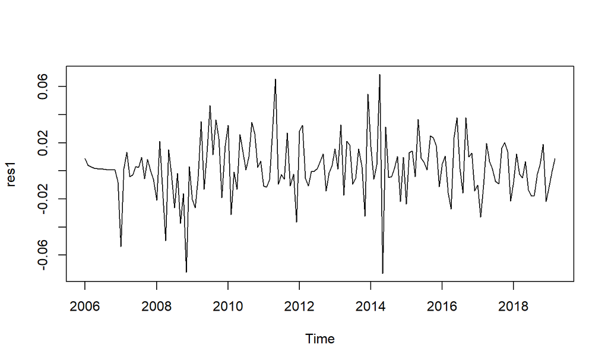

```r
plot(res1)
```

## 1. White noise assumption

Autocorrelation of the residuals (White noise assumption). What we expect is that all the coefficients are none significant, that is the deal with white noise. All coefficient seem to be none significant

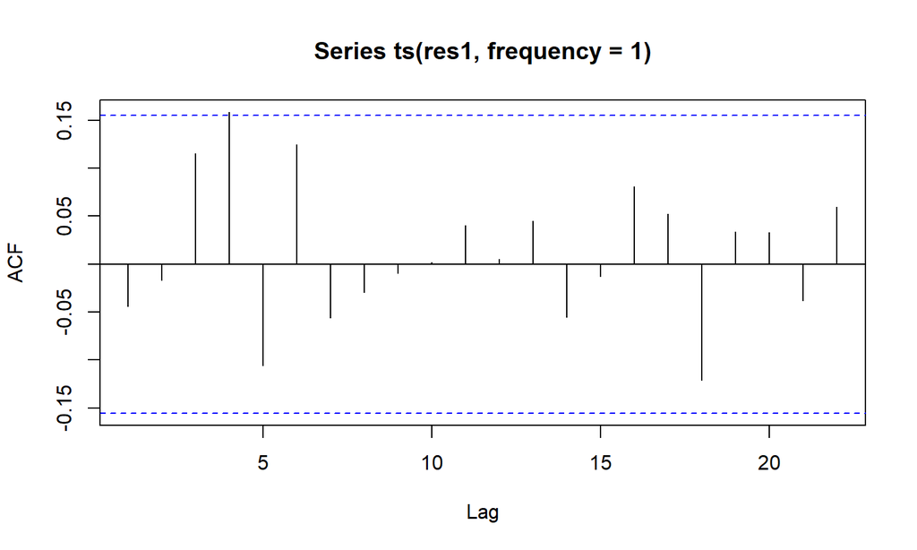

```r
acf(ts(res1, frequency=1))
```

What we expect is that all the coefficients are non significant, that is the deal with white noise it is not perfect but what would be like an issue if the first or the second autocorellation coefficient would have been significant. Here, 1 significant coefficient at lag 4

Same results for pacf.

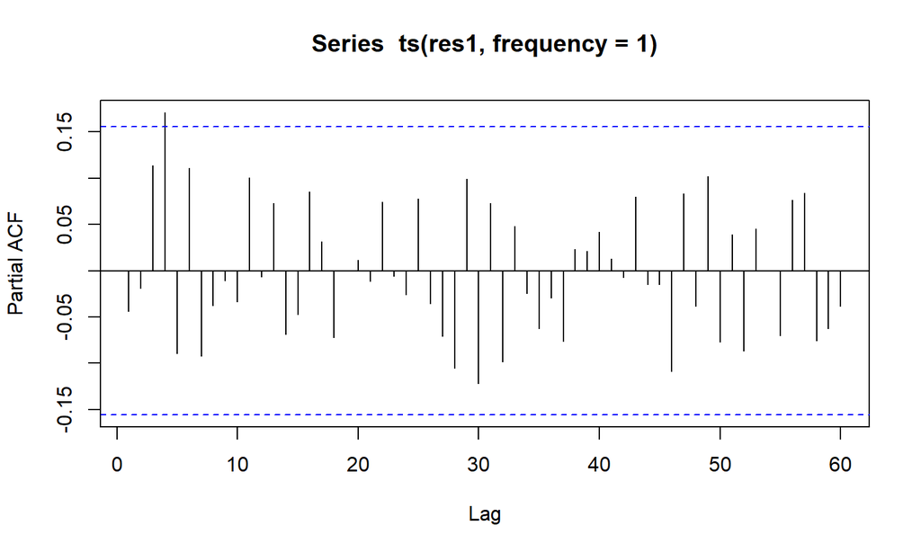

```r
pacf(ts(res1, frequency=1),lag.max = 60)
```

Ljung-box test to check for the significance of ACF

```r
Box.test(res1,lag=20,type="Ljung-Box")
```

```
##
##  Box-Ljung test
##
## data:  res1
## X-squared = 17.835, df = 20, p-value = 0.5983
```

pvalue = 59% larger than 5% so we accept H0: white noise assumption.  
Conclusion : **we have a white noise**.

## 2. Normality assumption

We compute standardized residuals (residuals divided by the standard deviation)

```r
res_stand <- res1/sqrt(mod1$sigma2)
summary(res_stand)
```

```
##     Min.  1st Qu.   Median     Mean  3rd Qu.     Max.
## -3.38079 -0.44527  0.05866  0.08838  0.60990  3.18516
```

if the normality assumption is satisfied, the standardized residuals should lie in between -2 and 2 (with 95% of chance)

It should be 95% of chance but here obviously there are some pics around 2007, 2009, 2011, 2014. We can identify outliers in the dataset it corresponds to the lowest and highest values of the residuals.

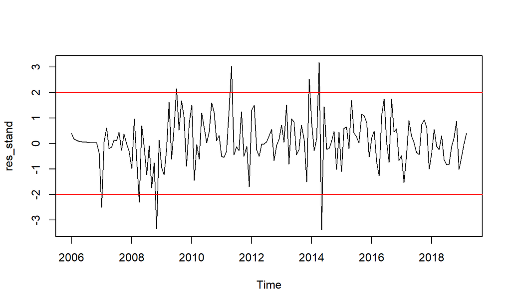

```r
plot(res_stand)
abline(a=2,b=0,col="red")
abline(a=-2,b=0,col="red")
```

2 options with this kind of situation :

1. Whether we decide it is a non possible value and change this value with what happens before
2. Transform them in dummies.

We will choose second option. But, before doing that, we need to check if it is necessary by testing the normality of the residuals.

Here, from the qq plot we can notice that our model data does not follow qqline which follows normal distribution. Let’s confirm this observation with Shapiro-wilk normality test.

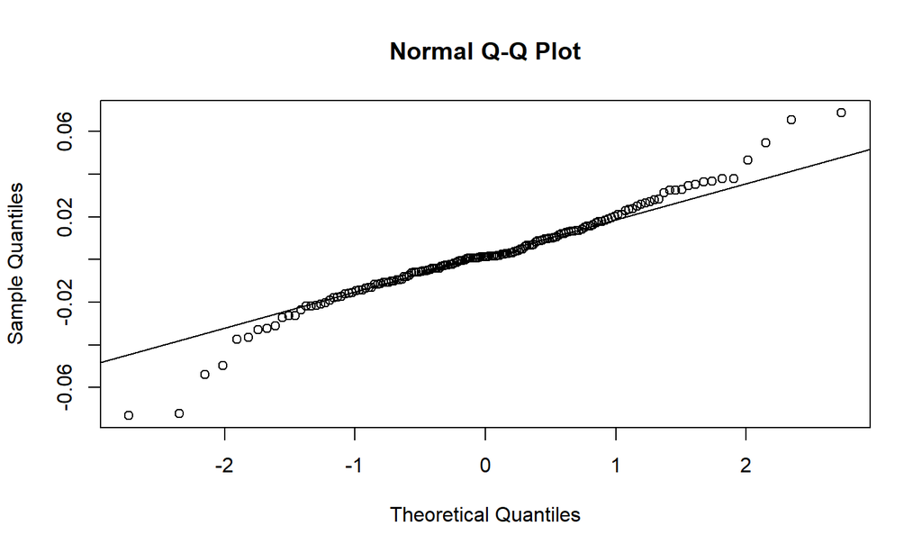

```r
qqnorm(res1)
qqline(res1)
```

Shapiro-test

```r
shapiro.test(res1)
```

```
##
##  Shapiro-Wilk normality test
##
## data:  res1
## W = 0.96687, p-value = 0.0007304
```

```r
jarque.bera.test(res1)
```

```
##
##  Jarque Bera Test
##
## data:  res1
## X-squared = 27.518, df = 2, p-value = 1.058e-06
```

pvalue <<<< 5%, we reject normality (H0 : normal, H1 non normal). We need to add a dummy in the model (second option)